# A Soil Property Analysis of America’s Rock Climbing Areas

##### Soil Properties Chart Collection

After plotting each soil property and saving the charts I created an image of all 8 charts for easy viewing and comparison.

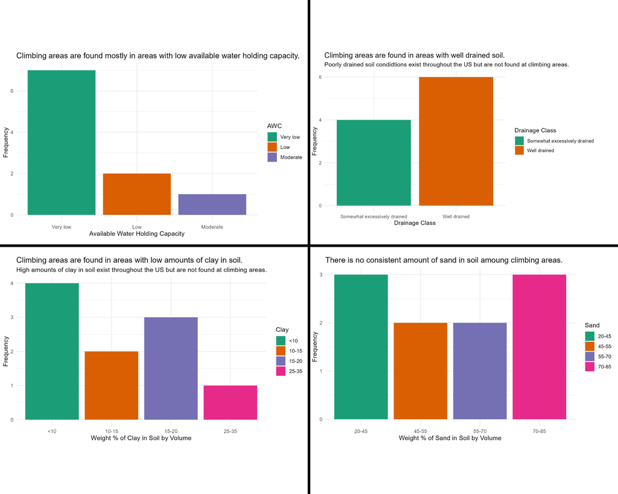

[figure not shown]

#### Data for analysis question 4: Does the type of climbing differ between West, Central, and Eastern regions?

First, I make smaller data frames for climbing areas from each region

```r
west <- subset(df, state %in% c("California", "Nevada", "Colorado", "Oregon", "Utah"))
central <- subset(df, state == "Kentucky")
east <- subset(df, state == "New York")
```

Next, I aggregate the number of routes for each type of climbing in each region and divide by the total number of climbs in that region to obtain a percentage that is comparable with other regions

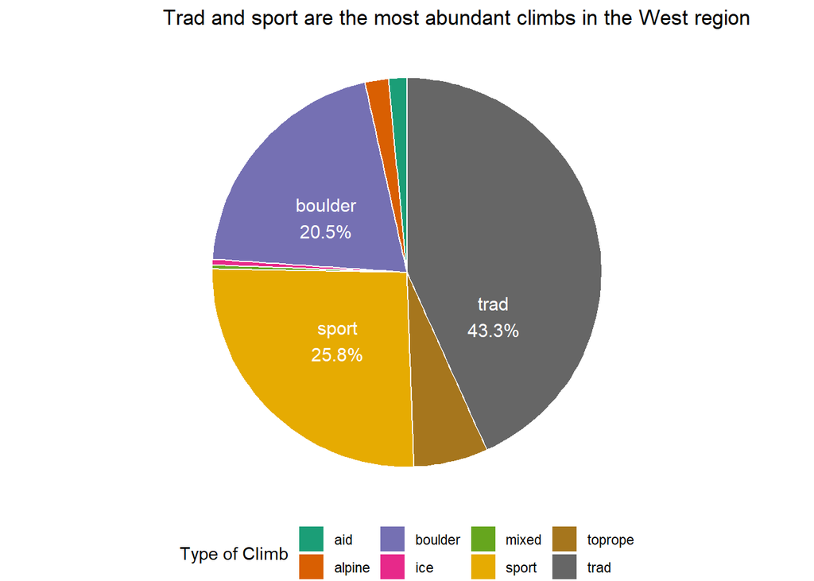

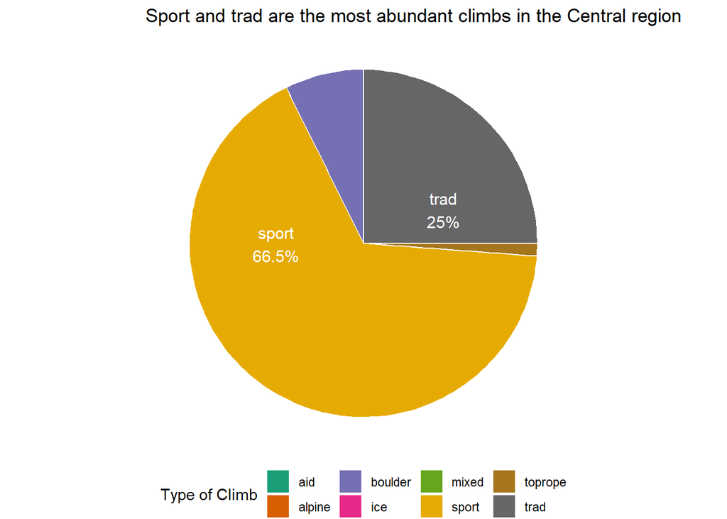

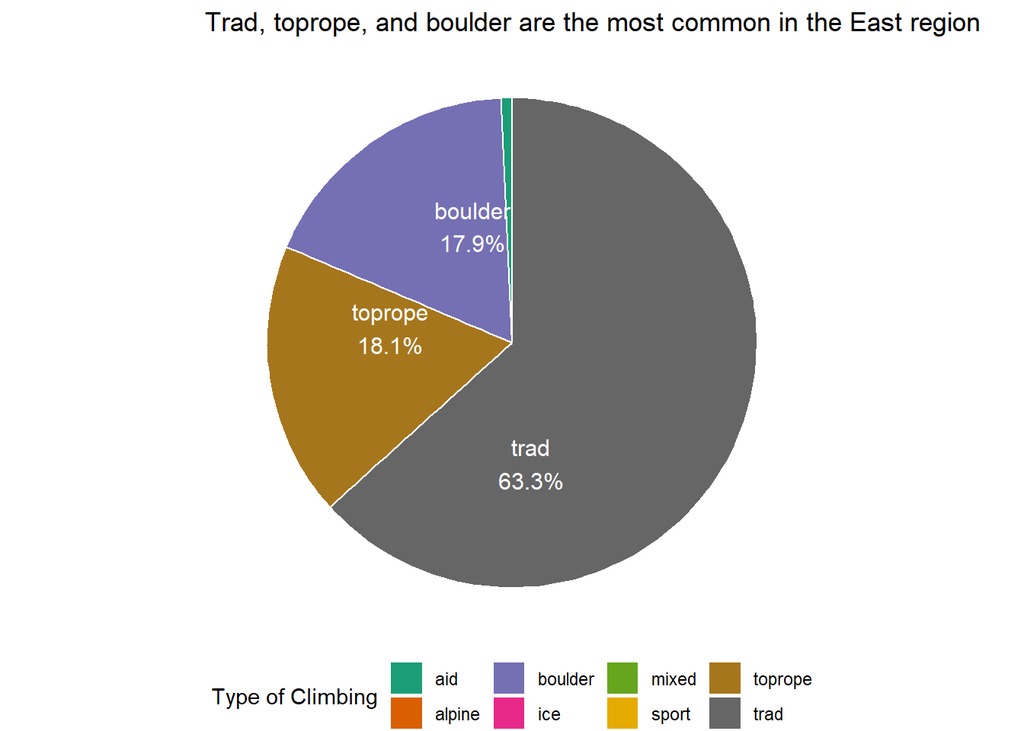

```r
trad <- sum(west$trad_climbs)
sport <- sum(west$sport_climbs)
toprope <- sum(west$toprope_climbs)
boulder <- sum(west$boulder_climbs)
ice <- sum(west$ice_climbs)
aid <- sum(west$aid_climbs)
mixed <- sum(west$mixed_climbs)
alpine <- sum(west$alpine_climbs)
west_totals <- data.frame(trad, sport, toprope, boulder, ice, aid, mixed, alpine)

#make the data frame long instead of wide for easier plotting
west_totals <- gather(west_totals, key="Category", value = "Total")

#make a percentage column
west_totals$percentage <- west_totals$Total / sum(west_totals$Total) * 100

#make the pie chart
ggplot(west_totals, aes(x = 1, y = percentage, fill = Category)) +
  geom_bar(stat = "identity", width = 1, color = "white") +
  coord_polar(theta = "y") +
  theme_void() +
  theme(legend.position = "bottom") +
  scale_fill_brewer(palette = "Dark2") +
  labs(title = "Trad and sport are the most abundant climbs in the West region", fill = "Type of Climb") +
  geom_text(data = subset(west_totals, percentage > 20),
            aes(label = paste0(Category, "\n", round(percentage, 1), "%")),
            position = position_stack(vjust = 0.75),
            color = "white",
            size = 4)
ggsave("west.png")
#same process for central
trad <- sum(central$trad_climbs)
sport <- sum(central$sport_climbs)
toprope <- sum(central$toprope_climbs)
boulder <- sum(central$boulder_climbs)
ice <- sum(central$ice_climbs)
aid <- sum(central$aid_climbs)
mixed <- sum(central$mixed_climbs)
alpine <- sum(central$alpine_climbs)
central_totals <- data.frame(trad, sport, toprope, boulder, ice, aid, mixed, alpine)

central_totals <- gather(central_totals, key="Category", value = "Total")

central_totals$percentage <- central_totals$Total / sum(central_totals$Total) * 100

ggplot(central_totals, aes(x = 1, y = percentage, fill = Category)) +
  geom_bar(stat = "identity", width = 1, color = "white") +
  coord_polar(theta = "y") +
  theme_void() +
  theme(legend.position = "bottom") +
  scale_fill_brewer(palette = "Dark2") +
  labs(title = "Sport and trad are the most abundant climbs in the Central region", fill = "Type of Climb") +
  geom_text(data = subset(central_totals, percentage > 20),
            aes(label = paste0(Category, "\n", round(percentage, 1), "%")),
            position = position_stack(vjust = 0.75),
            color = "white",
            size = 4)
ggsave("central.png")
#same process for east
trad <- sum(east$trad_climbs)
sport <- sum(east$sport_climbs)
toprope <- sum(east$toprope_climbs)
boulder <- sum(east$boulder_climbs)
ice <- sum(east$ice_climbs)
aid <- sum(east$aid_climbs)
mixed <- sum(east$mixed_climbs)
alpine <- sum(east$alpine_climbs)
east_totals <- data.frame(trad, sport, toprope, boulder, ice, aid, mixed, alpine)

east_totals <- gather(east_totals, key="Category", value = "Total")

east_totals$percentage <- east_totals$Total / sum(east_totals$Total) * 100

ggplot(east_totals, aes(x = 1, y = percentage, fill = Category)) +
  geom_bar(stat = "identity", width = 1, color = "white") +
  coord_polar(theta = "y") +
  theme_void() +
  theme(legend.position = "bottom") +
  scale_fill_brewer(palette = "Dark2") +
  labs(title = "Trad, toprope, and boulder are the most common in the East region", fill = "Type of Climbing") +
  geom_text(data = subset(east_totals, percentage > 15),
            aes(label = paste0(Category, "\n", round(percentage, 1), "%")),
            position = position_stack(vjust = 0.75),
            color = "white",
            size = 4)
ggsave("east.png")
```